# Lab1 - Checkpoint 1

## 1 Panorama

# a)

Ao receber os dados a minha primeira curiosidade foi ver como seria a distribuição dos gastos dos parlamentares de acordo com o tipo do gasto, que é representado pela variável txtDescricao.

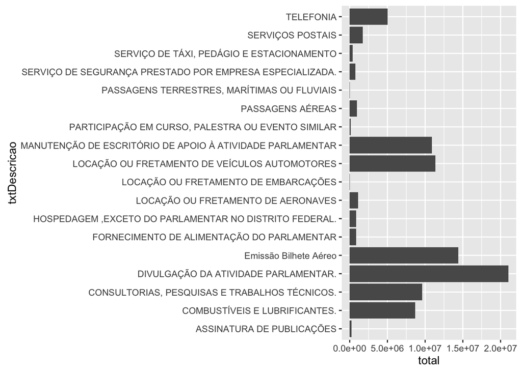

```r
panorama <- group_by(ano.atual,txtDescricao)
panorama_sum <- summarise(panorama, total=sum(vlrLiquido)) %>% arrange(desc(total))

p <- ggplot(panorama_sum, aes(txtDescricao,total))
p + geom_bar(stat="identity", position = "dodge") + coord_flip()
```

Podemos ver que no total, o maior gasto é com Divulgação de Atividade Parlamentar, seguido por Emissão de Bilhete Aéreo. Todavia, analisar a soma não nos dá muita informação, por isso decidi dar um zoom maior em como esses gastos são distribuidos dentro de cada um dessas categorias.

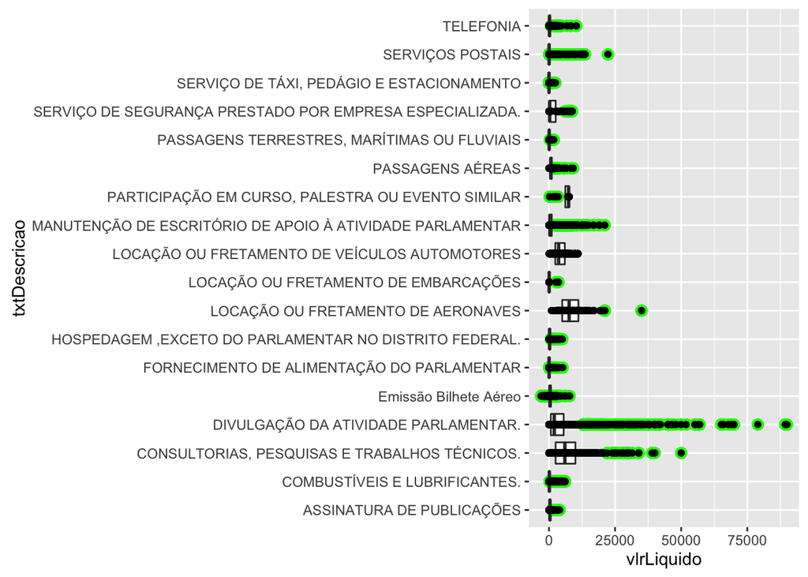

```r
vL <- ggplot(panorama, aes(txtDescricao,vlrLiquido))

vL + geom_boxplot(outlier.colour = "green", outlier.size = 3) + geom_point() + coord_flip()
```

# b)

De acordo com o último gráfico vemos que os gastos não são simétricos, ou seja, não tendem a se concentrar em uma região específica. O mais surpreende nesses dados são a quantidade de gastos atípicos, que são representados pelos pontinhos verdes e também dos valores negativos na parte de Emissão de Bilhetes Aéreos.

# c)

Sugeriria a escolha de uma categoria e o estudo mais aprofundado desses dados atípicos, tentaria isolar esses dados e testaria se eles tem correlação com alguma variável ainda não estudada, como o tempo por exemplo.

## 2 Respostas

# a) Em que tipo de despesas nossos parlamentares gastam mais recursos de sua cota?

```r
summarise(panorama, total=sum(vlrLiquido)) %>% arrange(desc(total))
```

```
## # A tibble: 18 x 2
##                                                 txtDescricao       total
##                                                       <fctr>       <dbl>
## 1                       DIVULGAÇÃO DA ATIVIDADE PARLAMENTAR. 21034115.12
## 2                                      Emissão Bilhete Aéreo 14382397.72
## 3              LOCAÇÃO OU FRETAMENTO DE VEÍCULOS AUTOMOTORES 11350924.27
## 4  MANUTENÇÃO DE ESCRITÓRIO DE APOIO À ATIVIDADE PARLAMENTAR 10878433.24
## 5              CONSULTORIAS, PESQUISAS E TRABALHOS TÉCNICOS.  9622983.39
## 6                              COMBUSTÍVEIS E LUBRIFICANTES.  8677612.52
## 7                                                  TELEFONIA  5006695.40
## 8                                           SERVIÇOS POSTAIS  1713831.60
## 9                         LOCAÇÃO OU FRETAMENTO DE AERONAVES  1106194.20
## 10                                          PASSAGENS AÉREAS   951491.10
## 11                FORNECIMENTO DE ALIMENTAÇÃO DO PARLAMENTAR   861521.48
## 12    HOSPEDAGEM ,EXCETO DO PARLAMENTAR NO DISTRITO FEDERAL.   839394.40
## 13  SERVIÇO DE SEGURANÇA PRESTADO POR EMPRESA ESPECIALIZADA.   729508.23
## 14                 SERVIÇO DE TÁXI, PEDÁGIO E ESTACIONAMENTO   393985.68
## 15                                 ASSINATURA DE PUBLICAÇÕES   237454.34
## 16         PARTICIPAÇÃO EM CURSO, PALESTRA OU EVENTO SIMILAR   145570.11
## 17               PASSAGENS TERRESTRES, MARÍTIMAS OU FLUVIAIS    44853.26
## 18                      LOCAÇÃO OU FRETAMENTO DE EMBARCAÇÕES     7508.36
```

Podemos observar nesse rank que os dois maiores gastos são com:

1 - Divulgação da Atividade Parlamentar 2 - Emissão de Bilhete Aéreo

# b) Quais tipos de despesas têm despesas que mais variam, que têm valores mais desiguais?

```r
summarise(panorama, desvio=sd(vlrLiquido)) %>% arrange(desc(desvio))
```

```
## # A tibble: 18 x 2
##                                                 txtDescricao     desvio
##                                                       <fctr>      <dbl>
## 1                       DIVULGAÇÃO DA ATIVIDADE PARLAMENTAR. 6933.07766
## 2              CONSULTORIAS, PESQUISAS E TRABALHOS TÉCNICOS. 6201.00473
## 3                         LOCAÇÃO OU FRETAMENTO DE AERONAVES 5372.44209
## 4   SERVIÇO DE SEGURANÇA PRESTADO POR EMPRESA ESPECIALIZADA. 2731.27446
## 5              LOCAÇÃO OU FRETAMENTO DE VEÍCULOS AUTOMOTORES 2602.30915
## 6          PARTICIPAÇÃO EM CURSO, PALESTRA OU EVENTO SIMILAR 2596.49168
## 7  MANUTENÇÃO DE ESCRITÓRIO DE APOIO À ATIVIDADE PARLAMENTAR 1601.27303
## 8                       LOCAÇÃO OU FRETAMENTO DE EMBARCAÇÕES  912.49204
## 9                                           PASSAGENS AÉREAS  739.94886
## 10                             COMBUSTÍVEIS E LUBRIFICANTES.  630.64509
## 11                                     Emissão Bilhete Aéreo  578.12666
## 12                                          SERVIÇOS POSTAIS  517.19651
## 13    HOSPEDAGEM ,EXCETO DO PARLAMENTAR NO DISTRITO FEDERAL.  437.87845
## 14                                                 TELEFONIA  437.78492
## 15                                 ASSINATURA DE PUBLICAÇÕES  415.26898
## 16               PASSAGENS TERRESTRES, MARÍTIMAS OU FLUVIAIS  134.81241
## 17                FORNECIMENTO DE ALIMENTAÇÃO DO PARLAMENTAR  111.58773
## 18                 SERVIÇO DE TÁXI, PEDÁGIO E ESTACIONAMENTO   88.39125
```

Podemos observar nesse rank que os dois gastos que mais varião são:

1 - Divulgacção da Atividade Parlamentar 2 - Consultorias, Pesquisas e Trabalhos Técnicos